# Capillary Electrophoresis JSON-LD

Erika Imada Barcelos, Laura S. Bruckman, Roger H. French

2023-08-09

## Capillary Electrophoresis JSON-LD Description

Capillary Electrophoresis (CE) is a separation method in which ions are separated based on their ionic charge and electrophoretic mobility using an applied voltage. One of the main advantages of CE is the usage of lower sample volumes compared to traditional separation methods, such as high performance liquid chromatography (HPLC).

In a CE experiment, ions in a sample are separated according to their mobility which is translated into a chromatogram, where the time the ions take to go through the capillary and detector signal (absorbance) is captured and recorded. Sample information as well as the experimental metadata and separation results (absorbance and time) are important variables in this experiment.

## Creating JSON-LD for CE in R

```r
library(FAIRmaterials)

# An example data frame for CE
CE_exp <- data.frame(
  'bufferpH' = c('7.4', '6.8'),
  'appliedVoltage' = c('26', '30'),
  'columnTemperature' = c('50C', '60C'),
  'capillaryLength' = c('15cm', '30cm'),
  'capillaryMaterial' = c('silica', 'polyacrylamide')
)

# This will generate JSON-LD file for the example data
output <- fairify_data(CE_exp, domain = 'CapillaryElectrophoresis', saveLocal = TRUE)
```

## Creating JSON-LD for CE in Python

```python
from fairmaterials.fairify_data import *
import pandas as pd

# An example data frame for CE
CE_exp = pd.DataFrame  ('bufferpH' = [7.4, 6.8],
  'appliedVoltage' = [26, 30],
  'columnTemperature' = [50, 60],
  'capillaryLength' = [15, 30],
  'capillaryMaterial' = ['silica', 'polyacrylamide'])

# This will generate JSON-LD file for the example data
output <- fairify_data(CE_exp, domain = 'CapillaryElectrophoresis')
```

## CE schema diagram

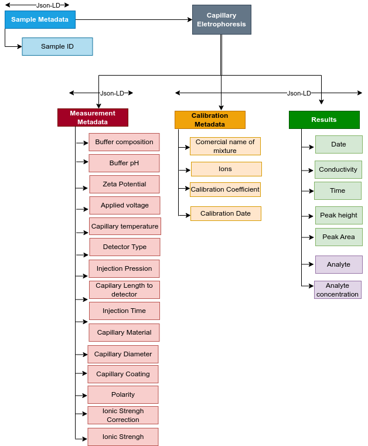

CE Schema

## References

https://chem.libretexts.org/Bookshelves/Analytical_Chemistry/Supplemental_Modules_(Analytical_Chemistry)/Instrumentation_and_Analysis/Capillary_Electrophoresis, https://www.shsu.edu/~chm_tgc/primers/pdf/CE.pdf

## Acknowledgment

This material is based upon work in the CASFER National Science Foundation (NSF) Engineering Research Center under the under Grant No 2133576 sub award 21P735-03